# Statistical Power Analysis for Transcriptomics Experiments

Bulk, Single-Cell, and Spatial RNA-seq

UF Health Cancer Center BCB-SR Bioinformatics Unit

2025-10-10

## Overview

**Paper:** Statistical Power Analysis for Designing Bulk, Single-Cell, and Spatial Transcriptomics Experiments

**Authors:** Jeon et al., 2023, *Biomolecules*

**Today’s Agenda:**

1. Power analysis fundamentals
2. Bulk RNA-seq: Considerations & demo
3. Single-cell RNA-seq: Considerations & demos
4. Spatial transcriptomics: Considerations & challenges
5. Discussion questions

## Poll: Have You Done Power Analysis for Transcriptomics?

**Un-mute for 1, 2, or 3!**

1. I always do power analysis for my transcriptomics experiments
2. I have done it or heard about it at some point
3. I have not done or come across power analysis for transcriptomics

## The Expensive Problem

**Too Few Samples:**

- Waste time and money
- Miss real biology
- Underpowered studies

**Too Many Samples:**

- Waste money
- Waste precious samples

**How do we know the right number?**

## What is Statistical Power?

**Statistical Power** = Probability of detecting a true effect when it exists

$$\text{Power} = P(\text{reject } H_0 | H_0 \text{ is false})$$

Or simply: **Your chance of finding real biology**

## What is Power Analysis?

**Power Analysis** = Systematic examination of the relationship between power and experimental design parameters

**Key parameters that affect power:**

- Sample size (biological replicates)
- Effect size (how big is the change?)
- Sequencing depth
- Significance threshold (α, FDR)
- Biological variability

## Power Analysis Goals

**Prospective (before experiment):**

- Determine optimal experimental design
- Balance cost vs. statistical power
- Avoid under- or over-sampling

**Retrospective (after experiment):**

- Evaluate achieved power
- Interpret negative results
- Plan follow-up studies

### Power in Transcriptomics: A Key Difference

**Classical power analysis:**

- One outcome → One hypothesis test
- Power = Probability of rejecting H₀ when H₀ is false
- Example: “80% probability of detecting the treatment effect”

**Transcriptomics power analysis:**

- Thousands of genes → Thousands of tests simultaneously
- Each gene has its own power (based on expression, variability, effect size)
- **Reported power = Average power across all genes**

### Why This Matters Practically

**When a tool reports “80% power”:**

**Genes you’ll likely detect (>90% power):**

- Highly expressed genes with large fold-changes

**Genes you’ll likely miss (<50% power):**

- Lowly expressed genes with small fold-changes

**Genes in the middle (50-80% power):**

- This is where your sample size decision matters most

**Many tools report stratified power by expression level**

## Key Concepts: The Glossary

| Term | Meaning |
| --- | --- |
| **Statistical Power** | Your chance of finding real DEGs |
| **Effect Size** | How big is the fold-change? |
| **FDR** | Of your hits, how many are false? |
| **Sequencing Depth** | Reads per sample |
| **Biological Replicates** | Different individuals (CRITICAL) |

**Key takeaway:** More biological replicates > deeper sequencing

## The Three Technologies

Each technology has different:

- Data characteristics
- Research questions
- Cost structures
- Power considerations

**Let’s examine each in detail…**

# Bulk RNA-seq

## Bulk RNA-seq: Technology Overview

**Technology:** Next-generation sequencing of RNA from cell populations

**Data characteristics:**

- Gene expression measured as read counts
- Highly reproducible (technical replicates unnecessary)
- Follows negative binomial distribution

**Primary research objective:**

- Detect differentially expressed genes (DEGs) between conditions

### Bulk RNA-seq: Power Considerations

**Key experimental factors affecting power:**

- Number of biological replicates (most influential)
- Sequencing depth (affects technical precision)
- Gene-specific parameters: mean expression and dispersion
- Effect size distribution (expected fold-changes)
- Target FDR level (typically 0.05 or 0.10)

**Critical findings:**

- Biological replicates > sequencing depth for power
- Gene-specific parameters from pilot data improve accuracy
- Rule of thumb: 6-8 biological replicates

### Bulk RNA-seq: Available Tools

| Tool | Approach | Key Features |
| --- | --- | --- |
| ssizeRNA | Analytical | Fast, FDR control, accurate |
| RnaSeqSampleSize | Analytical | Conservative, may overestimate |
| PROPER | Simulation | Flexible but slower |
| RNASeqPower | Analytical | Single gene focus |

**Recommended: ssizeRNA**

### Demo: ssizeRNA for Bulk RNA-seq

**Scenario:** 10,000 genes, expecting 20% differentially expressed

**Parameters:**

- Total genes = 10,000
- Proportion non-DE = 0.8
- Average read count = 10
- Dispersion = 0.1
- Fold change = 2
- Target FDR = 0.05
- Desired power = 0.8

```r
size1 <- ssizeRNA_single(
  nGenes = 10000,
  pi0 = 0.8,
  m = 200,
  mu = 10,
  disp = 0.1,
  fc = 2,
  fdr = 0.05,
  power = 0.8,
  maxN = 20
)
```

### Demo: ssizeRNA Results

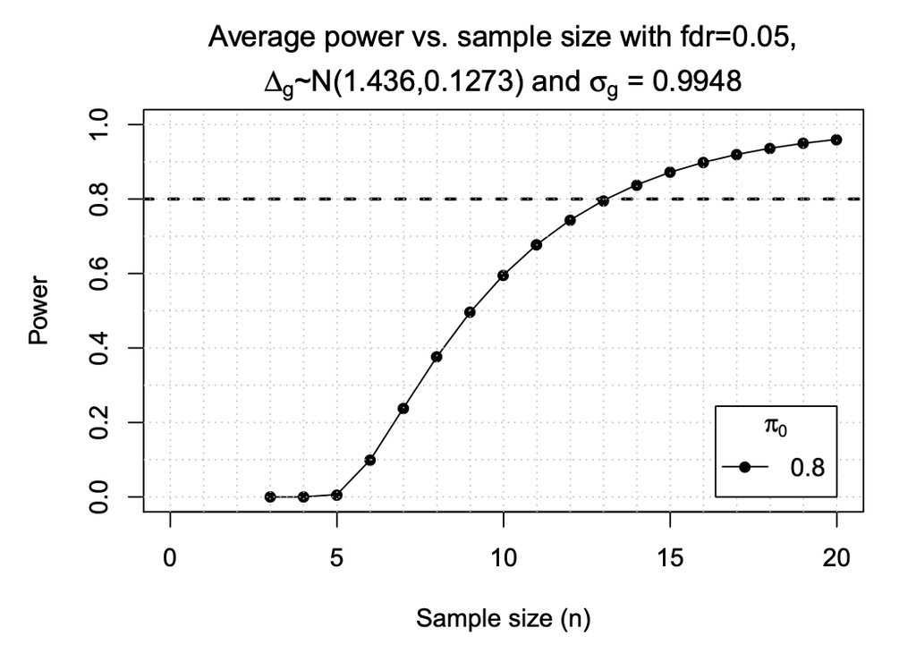

**Result: “Power = 0.80” means:**

- **Expected proportion (assumption):** 80% of the 2,000 true DEGs
- **Expected number detected:** ~1,600 genes (400 false negatives)
- **Average detection rate:** Weighted average across all DE genes

**Result: Need n=14 samples per group**

- Of 2,000 true DEGs, expect to detect approximately 1,600
- 400 false negatives expected
- Weighted average across all gene characteristics

### ssizeRNA: Three Scenarios

|  | Single Parameter | Gene-Specific, Fixed FC | Fully Gene-Specific |
| --- | --- | --- | --- |
| Input | One mean, dispersion, FC | Gene-specific mean/dispersion + single FC | Gene-specific mean/dispersion + FC distribution |
| Best for | Minimal pilot data | Pilot data, similar effects | Good pilot data, variable effects |
| Trade-off | Very conservative | More realistic, still conservative | Most realistic and accurate |

## Bulk RNA-seq: Key Takeaways

1. Biological replicates matter most
2. Use pilot data for gene-specific parameters
3. ssizeRNA is recommended tool
4. Expect heterogeneity in power across genes
5. Plan conservatively

# Single-Cell RNA-seq

## Single-Cell RNA-seq: Technology Overview

**Technology:** Individual cell-level RNA sequencing

**Data characteristics:**

- Cell-level gene expression resolution
- High proportion of zeros (sparsity)
- Hierarchical structure (cells within individuals)
- Greater variability than bulk RNA-seq

**Three main research objectives:**

1. Cell subpopulation detection
2. Differential cell abundance
3. Differential gene expression

### Single-Cell RNA-seq: Power Considerations (1/3)

**Three Main Research Objectives:**

1. Cell subpopulation detection
2. Differential cell abundance
3. Differential expression

Added complexity relative to bulk RNA-seq

### Single-Cell RNA-seq: Power Considerations (2/3)

**Added Complexity:**

- Dual sample size problem (cells AND individuals)
- Greater proportion of zeros and variability
- Hierarchical structure (cells nested in individuals)
- Zero-inflation requires specialized models

### Single-Cell RNA-seq: Power Considerations (3/3)

**Key Experimental Factors:**

- Cell subpopulation proportions
- Number of cells per sample
- Number of biological replicates
- Sequencing depth
- Batch effects
- Experimental design

**Key finding:** More replicates > more cells per sample

## The Pseudoreplication Problem

**Wrong:** Treat all cells as independent samples

**Right:** Account for individual-level variation

**Takeaway:** Need biological replicates (individuals), not just technical replicates (cells)

### scRNA-seq: Available Tools

**Cell subpopulation detection:** SCOPIT, howmanycells

**Differential cell abundance:** scPOST, Sensei

**Differential expression (multi-sample):** scPower, hierarchicell

**Differential expression (single-sample):** POWSC, powsimR

### Demo: scPOST for Differential Cell Abundance (1/2)

**Research Question:** Can I detect expansion of HLA-DRA+ fibroblasts in disease vs. healthy?

**Required Inputs:**

- Cell state annotations (from clustering)
- Sample annotations (individual IDs)
- Batch annotations
- Principal components from PCA

### Demo: scPOST for Differential Cell Abundance (1/2)

**Core Functions:**

```r
# Step 1: Estimate cell state frequency variation
freqEstimates <- estimateFreqVar(
  meta = data$meta,
  clusCol = 'celltype',
  sampleCol = 'sample'
)

# Step 2: Estimate gene expression variation
pcEstimates <- estimatePCVar(
  pca = data$pca,
  npcs = 20,
  meta = data$meta,
  clusCol = 'celltype',
  sampleCol = 'sample',
  batchCol = 'batch'
)
```

### Demo: scPOST for Differential Cell Abundance (2/2)

Simulate and Test:

```r
# Step 3: Simulate datasets and perform association testing
simDataset.withMASC(
  ncases = 17, nctrls = 3,  # Study design
  ncells = 250,              # Cells per sample
  centroids = pcEstimates$centroids,
  batch_vars = pcEstimates$batch_vars,
  sample_vars = pcEstimates$sample_vars,
  meanFreqs = freqEstimates$meanFreq,
  fc = 5                     # Fold-change to induce
)

# Step 4: Calculate power
getPowerFromRes(resFiles, resTables, threshold = 0.05)
```

### Demo: scPOST Example Results (5-fold expansion, 500 simulations):

| STUDY DESIGN | CASES | CONTROLS | POWER |
| --- | --- | --- | --- |
| Unbalanced | 17 | 3 | 12% |
| Balanced | 10 | 10 | 60% |

**Key finding:** Balanced designs dramatically increase power

### Demo 2: Differential Expression in scRNA-seq

**Question:** Can I detect DEGs between conditions within a cell type?

**Scenario:**

- Cell type: T cells
- Expected fold-change: 2
- Cells per sample: 500
- How many biological replicates?

**Tool:** scPower

### Demo 2: Differential Expression in scRNA-seq with scPower

[demo](https://scpower.helmholtz-muenchen.de/)

## scRNA-seq: Key Takeaways

1. Shallow sequencing of many cells > deep sequencing of few cells
2. Optimal read depth is surprisingly low (~10k reads/cell)
3. Sample size depends on effect size (large n for small effects)
4. Biological replicates essential for valid inference
5. Different applications need different designs (DE vs annotation vs co-expression)
6. Use well-matched priors when planning studies

# Spatial Transcriptomics

## Spatial Transcriptomics: Technology Overview

**Two main types:**

**Imaging-based:** Single-cell resolution, limited genes

**Sequencing-based:** Spot-level resolution, genome-wide

**Key addition:** Spatial coordinates preserved

### Spatial Transcriptomics: Research Questions

**Three main goals:**

1. Spatially variable genes
2. Tissue architecture
3. Cell-cell communication

### Spatial Transcriptomics: Power Considerations

**Key experimental factors:**

- Number of fields of view
- Size of fields of view
- Choice of tissue area
- Number of cells or spots
- Spatial structure

### Spatial Transcriptomics: Current State

**Limited tools available:**

- Baker et al. simulation approach
- Bost et al. empirical FoV optimization
- poweREST for DE between two conditions

**Key findings:**

- Tissue complexity affects FoV requirements
- Tumor samples need more FoVs
- Size and number both matter

**Major limitation:** Power analysis tools are under-developed

### Demo: PoweREST for Spatial Transcriptomics

**Question:** Power to detect DE genes between two conditions/groups

[demo](https://lanshui.shinyapps.io/PoweREST/)

## Spatial Transcriptomics: Key Takeaways

1. Effect size and gene detection rate critically determine power
2. Single samples per group only provide adequate power with large fc
3. More spots per sample helps, but biological replicates needed for inference
4. Full R package needed, web app is very limited
5. Tissue-specific power surfaces available (pancreatic, colorectal cancer)

# Practical Considerations

## The Pilot Data Problem

**Where to get parameters?**

**Option 1:** Your own pilot data (most accurate, expensive)

**Option 2:** Public data (free, may not match perfectly)

**Tip:** Conservative estimates are okay

## Common Mistakes to Avoid

1. Using n=3 for everything
2. Treating cells as replicates
3. Sequencing deeper instead of more samples
4. Using wrong tool for technology
5. Ignoring batch effects
6. Unrealistic effect sizes

## When Can You Skip Power Analysis?

**Sometimes formal calculation is not feasible:**

- Exploratory studies
- Constrained samples (rare diseases)
- Following established protocols
- Hypothesis-generating studies

**But always consider minimum detectable effect size**

## Practical Workflow

**Before starting:**

1. Find similar published data
2. Run quick power calculation
3. Get ballpark sample size

**During planning:**

1. Budget for replicates FIRST
2. Balance number vs depth vs cells
3. Consider batch structure
4. Plan for failures

# Discussion

## Discussion Questions

1. What is your main barrier to using power analysis?
2. How does pseudoreplication change scRNA-seq design?
3. How would you plan spatial experiments?
4. How do you choose realistic effect sizes?
5. Should power analysis be required for publication?
6. How do you balance power with sample availability?

## Key Takeaways

1. Power analysis is important
2. Biological replicates > sequencing depth
3. Different technologies need different approaches
4. Tools exist and are usable
5. Balanced designs matter
6. Spatial is still developing

## Resources

**Paper:** Jeon et al. 2023, Biomolecules

**Software:**

- Bulk: ssizeRNA
- scRNA-seq: POWSC, scPower, scPOST, SCOPIT
- Spatial: Limited tools

**Key References:**

- Schurch et al. 2016
- Liu et al. 2014
- Squair et al. 2021

## Thank You!

**Questions?**

**Contact:** UFHCC-BCB-SR@ad.ufl.edu